# Graph Visualization

Vivek Anand

March 23, 2019

```r
## Library Declarations
library(igraph)
library(Matrix)
### 2008 Data
#### 1-edges.csv
edges1_dataframe<-read.csv("1-edges.csv",header=FALSE)
names(edges1_dataframe)<-c("Node1","Node2","Boolean Interaction")
#tail(edges1_dataframe,10)
nodes<-read.csv("nodes.csv",header=FALSE)
g1=graph_from_data_frame(d=edges1_dataframe, vertices=nodes, directed=FALSE)
contact_matrix1<-get.adjacency(g1,type="both")

#### 2-edges.csv
##### Not doing this yet as documentation is not good

#### 3-edges.csv
edges3_dataframe<-read.csv("3-edges.csv",header=FALSE)
names(edges3_dataframe)<-c("Node1","Node2","Number of Shared Subscriptions")
#edges3_dataframe[27288,c("Node1","Node2","Number of Shared Subscriptions")]

g3=graph_from_data_frame(d=edges3_dataframe, vertices=nodes, directed=FALSE)
contact_matrix3<-get.adjacency(g3,type="both")

#### 4-edges.csv
edges4_dataframe<-read.csv("4-edges.csv",header=FALSE)
names(edges4_dataframe)<-c("Node1","Node2","Number of Shared Subscribers")
g4=graph_from_data_frame(d=edges4_dataframe, vertices=nodes, directed=FALSE)
contact_matrix4<-get.adjacency(g4,type="both")

#### 5-edges.csv
edges5_dataframe<-read.csv("5-edges.csv",header=FALSE)
names(edges5_dataframe)<-c("Node1","Node2","Number of Shared favorite Videos")
g5=graph_from_data_frame(d=edges5_dataframe, vertices=nodes, directed=FALSE)
contact_matrix5<-get.adjacency(g5,type="both")
```

Now lets plot the degree distribution of the shared subscriber network.

```r
library(igraph)
shared_subscriber_degrees<-degree.distribution(g4)
length(shared_subscriber_degrees)
```

```
## [1] 5959
```

```r
head(shared_subscriber_degrees)
```

```
## [1] 0.307065217 0.003976670 0.004109226 0.004175504 0.003976670 0.001922057
```

```r
tail(shared_subscriber_degrees)
```

```
## [1] 0.000000e+00 0.000000e+00 0.000000e+00 0.000000e+00 0.000000e+00
## [6] 6.627784e-05
```

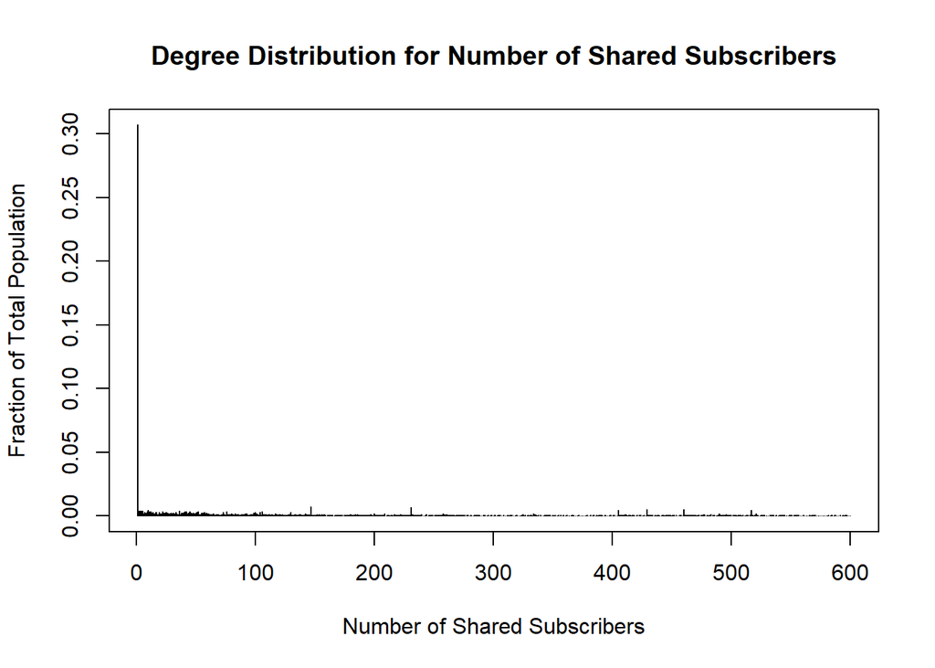

```r
plot(1:600,shared_subscriber_degrees[1:600],main="Degree Distribution for Number of Shared Subscribers",xlab="Number of Shared Subscribers",ylab="Fraction of Total Population","h")
```

Assume that in a sexually transmitted disease epidemic, there are a limited number of vaccines available. One has to find out whom to vaccinate to minimize the number of people infected.

1. *Randomly Sample one individual A from those who you know have been infected.*
2. *Ask A who he/she had intercourse with last. Assume this person is B.*
3. *Ask B who he/she had intercourse with last. Assume this person is C.*
4. *Vaccinate C.*
5. *Repeat several times.*

You have a high probability of having vaccinated the high risk individuals now. We will explain in class how this works.

For the youtube dataset however, we will modify the algorithm as follows.

Assume that each individual has a importance counter that is initialized to 0.

1. *Randomly sample one individual A from the entire network who has atleast one shared subscriber.*
2. *Find the person B who A has the most shared subscribers with.*
3. *Find person C who B has most shared subscribers with*
4. *Increase C’s importance counter by one. (This may be modified later)*
5. *Repeat several times.*

```r
vertices_g4<-V(g4)


algos<-function(nodes,samples){
  #Initial Variables
  num_nodes<-nrow(contact_matrix4)
  importance_counter<-numeric(num_nodes)
  current_count<-0
  #print(current_count)
  while (current_count<samples){
    # Sample A
    node_B=0
    # Handle case where node A does not have any neighbors
    while (node_B==0){
      node_A<-sample(nodes,size=1)
      #Get B
      node_B<-which(contact_matrix4[node_A,]==max(contact_matrix4[node_A,]))
      node_B<-sample(node_B,1)
      #print(node_B)
    }

    #C
    node_C<-which(contact_matrix4[node_B,]==max(contact_matrix4[node_B,]))
    importance_counter[node_C]<-importance_counter[node_C]+1
    current_count<-current_count+1

  }
  return(importance_counter)
}
```

```r
# Prepped data
nrow(contact_matrix4)
```

```
## [1] 15088
```

```r
ncol(contact_matrix4)
```

```
## [1] 15088
```

```r
contact_matrix4<-as.matrix(contact_matrix4)
cm_table<-which(contact_matrix4!=0,arr.ind = TRUE)
head(cm_table)
```

```
##         row col
## 282     282   4
## 14437 14437   4
## 329     329   8
## 644     644   8
## 3121   3121   8
## 3956   3956   8
```

```r
values<-cm_table[,"row"]
head(values,20)
```

```
##   282 14437   329   644  3121  3956  5088  5089  5090  5091  5092  5093
##   282 14437   329   644  3121  3956  5088  5089  5090  5091  5092  5093
##  5094  5095  5096  5097  5099  5100  5101  5102
##  5094  5095  5096  5097  5099  5100  5101  5102
```

```r
unique_value_nodes<-unique(values)
head(unique_value_nodes,20)
```

```
##  [1]   282 14437   329   644  3121  3956  5088  5089  5090  5091  5092
## [12]  5093  5094  5095  5096  5097  5099  5100  5101  5102
```

```r
#Run the model once
vec<-algos(unique_value_nodes,1)
```

[output not shown]

```r
head(vec)
```

```
## [1] 0 0 0 0 0 0
```

```r
tail(vec)
```

```
## [1] 0 0 0 0 0 0
```

```r
sum(vec)
```

```
## [1] 76
```

```r
#Maximum value
max(vec)
```

```
## [1] 1
```

```r
#Maximum value nodes
which(vec==max(vec))
```

```
##  [1]    24    46   102   106   113   118   149   153   163   680   789
## [12]  1593  1622  1804  2050  2394  2439  2763  2772  2775  2779  2780
## [23]  2801  2804  2808  2810  2813  2816  2856  2860  2889  2954  3025
## [34]  3392  3854  3935  4067  4559  4629  4789  4930  5003  5324  5337
## [45]  5352  5355  5356  5358  5376  5385  5387  5396  5547  5592  5602
## [56]  5610  5716  5916  6086  6390  6696  8606  8733  8743  8985  9464
## [67]  9535 10287 10288 10291 10498 11978 13313 13775 14162 14565
```

Now let’s try to simulate 100,000 iterations to get the maximum value properly

```r
lots_of_vec<-algos(unique_value_nodes,100000)
```

```r
sum(lots_of_vec)
```

```
## [1] 102018159
```

```r
#Max value
max(lots_of_vec)
```

```
## [1] 75844
```

```r
#Maximum value nodes
which(lots_of_vec==max(lots_of_vec))
```

```
## [1] 1189
```

One can iteratively obtain information and still get enough insights into the network without needing all the information all at once.

Of course, this can be improved by better methods of sampling or by changing the weight of the importance counter as a function of the number of shared neighbors but this is a great start for analyzing networks in an almost monte carlo approach.